# Part II - (Prosper Loan Dataset Analysis Outcome)

## by (Clinton Nwokocha)

## Investigation Overview

> The goals of this presentation is to outline features that iunfluence the borrower APR for each loan taken.

## Dataset Overview

The data is the Prosperloan dataset generated by the p2p lending industry based in Carlifornia, Properloan Marketplace, inc. This data set contains 113,937 loans with 81 variables on each loan, including loan amount, borrower rate (or interest rate), current loan status, borrower income, and many others. See this data dictionary to understand the dataset's variables.

```
(113937, 81)
<class 'pandas.core.frame.DataFrame'>
RangeIndex: 113937 entries, 0 to 113936
Data columns (total 81 columns):
 #   Column                               Non-Null Count   Dtype
---  ------                               --------------   -----
 0   ListingKey                           113937 non-null  object
 1   ListingNumber                        113937 non-null  int64
 2   ListingCreationDate                  113937 non-null  object
 3   CreditGrade                          28953 non-null   object
 4   Term                                 113937 non-null  int64
 5   LoanStatus                           113937 non-null  object
 6   ClosedDate                           55089 non-null   object
 7   BorrowerAPR                          113912 non-null  float64
 8   BorrowerRate                         113937 non-null  float64
```

[output cut: 74 more lines]

### looking at the main variable of interest: Borrower Annual Perecentage Rate, Is the distribution skewed or symmetric? Is it unimodal or multimodal?

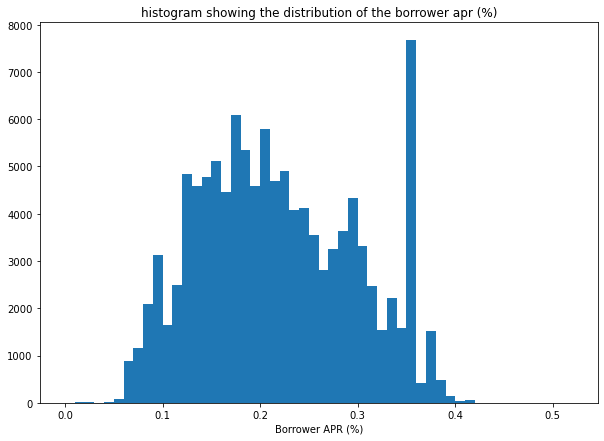

#### The borrower APR is showing a multimodal distribution which could indicate that the data could be coming from several different sub population, other features in the dataset could tell how much of a sub population we are looking at here.

### The borrower rate which is the interest rate is a major chunk of what makes up the annual percentage rate, looking at its values would give out how much difference at what amount is the other chunk

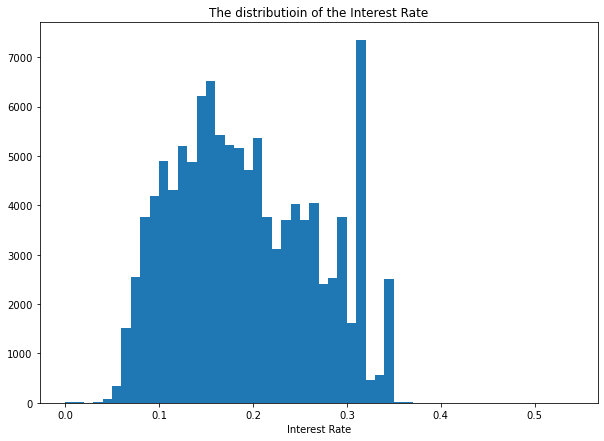

##### The chart of the interest rate looks very similar to that of the annual perecentage rate, this tells us that other rates are infinitesimal compared to the interest rate

### The term feature gives out the duration of these loans in months, is there an interesting pattern in these feature?

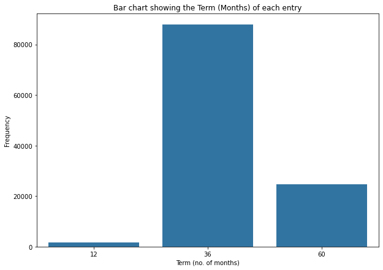

### It is noticed that most of the loans were for a duration of 36 months, with just few being for 12months

## What were the reasons for the loans?

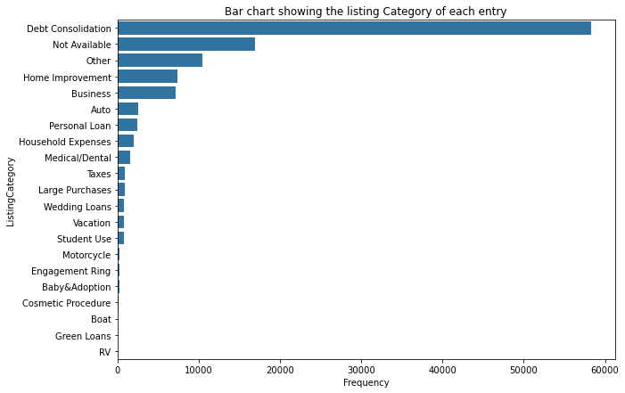

#### The loans were taking majorly to pay off debts,

#### whats the distribution of the loan amount like?

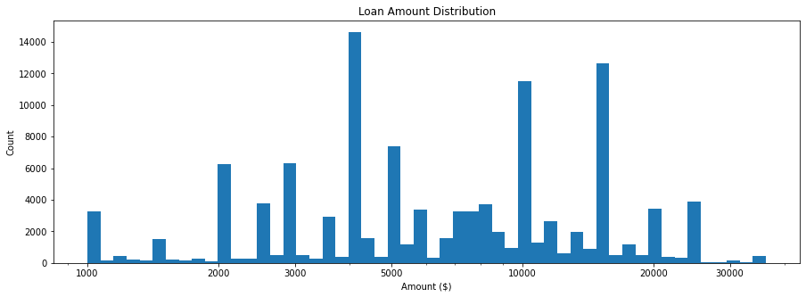

### The loan amount is multi modal and widely distributed supporting earlier observtations that the data comes from several different sub population

### exploring the loan status would give us a report on the the distribution of loan standing in the dataset loan standing

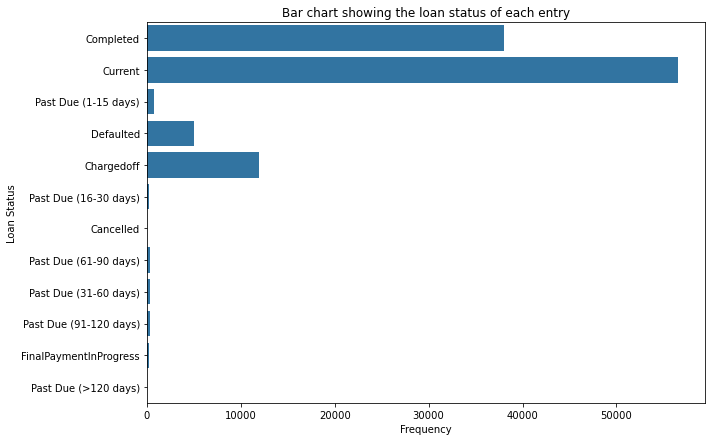

### The active and completed loans takes most points of the dataset

## The Ocuppation feature tell the occupation of individuals for each entry, whats the occupation of most people in the entry?

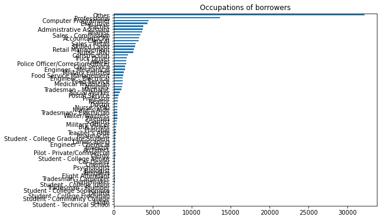

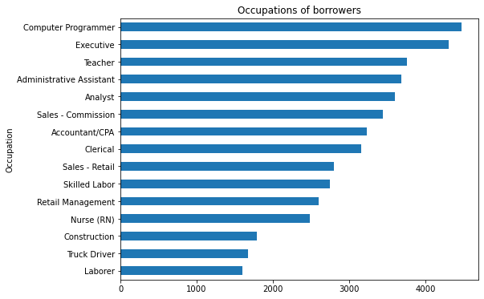

### The occupation is widely distributed

## The Employment status feature tells the status of each individual during the listing,

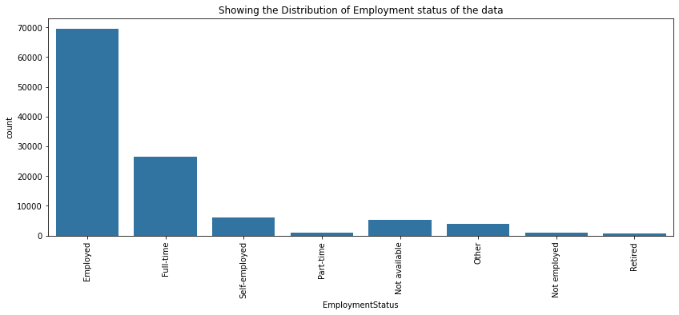

### From the above plot it is observed that most borrowers are employed, this could be based on the reasoning that income earners are more likely to finance their loan repayment using their monthly incomes. The not employed and retireed rarely features in this dataset.

## What is the distribution of the Debt to Income ratio of the entries in the datat set?

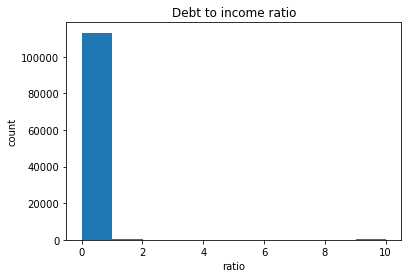

### This plot shows there is an outlier somewhere around the value 10, some scale transformation needs to be done for better representatiomn of the data

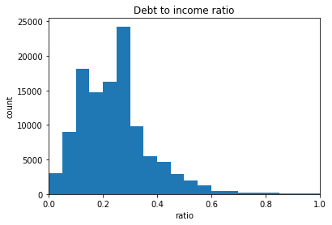

### The plots shows a right skewd distribution,its a bimodal distribution with most of the debt to income ratio values falling between 0.1-0.4

### Visualizing the income range to see if there are interesting patterns

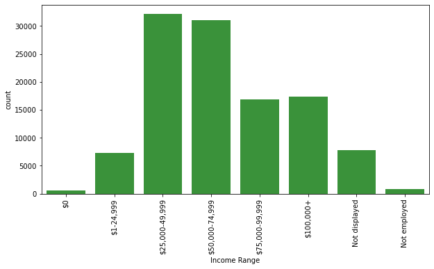

### It shows that most people that got loans were income earners, the not employed and non income earners were pooorly represented in the dataset.

### Check to observe what demographics of the dataset had required documents to support their investigations

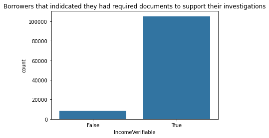

### Most of the demographic were ready to provide required documents for proof of income.

### Check to observe what demographics of the dataset are home owners

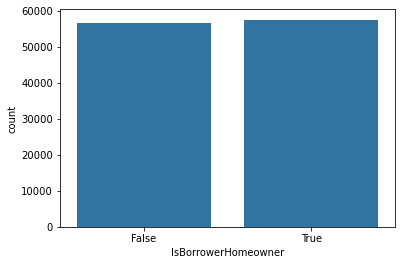

#### There isnt a clear difference in this representation with the home owners only having a slight edge.

### Discuss the distribution(s) of your variable(s) of interest. Were there any unusual points? Did you need to perform any transformations?

> The borrower APR is showing a multimodal distribution which could indicate that the data could be coming from several different sub population, It also shows a very similar distribution to the Borrower Interest Rate which isn't far fetched since the interest rate is what normally makes up bulk part of the Annual Percentage Rate.

### Of the features you investigated, were there any unusual distributions? Did you perform any operations on the data to tidy, adjust, or change the form of the data? If so, why did you do this?

> During the features investigation, the debt to income ratio was highly skewd to the right so limits were set, to further understand the distribution better. The listing category had to be mapped with much more descriptive terms for better understand of their implications.

## The borrower rate and borrower apr showed similar pattern as univariates, would there be any unusual distribution if both are plotted together on a chart?

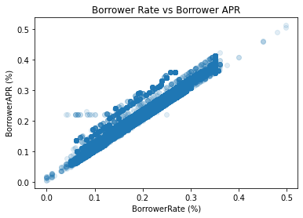

#### There is a positive correlation between the interest rate and annual percentage rate which confirms our earlier bias

## Checking if there was any influence on the borrower owning a home with the annual Percentage rate

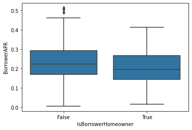

#### The plot shows that Borrowers that own homes tend to have a lower borrower annual percentage rate, this has more to do with the confidence of the lenders, apparently you would be comfortable granting loans to people with assets.

## What impact does the lenght of the loan have on the Borrower Annual Percentage Rate

[figure not shown]

### The loans for the duration of 12 months seem to have a very slight average compared to those of 36 and 60 months, regardless the averages arent that very much

## What influence does the loan amount have on the duration of the loan

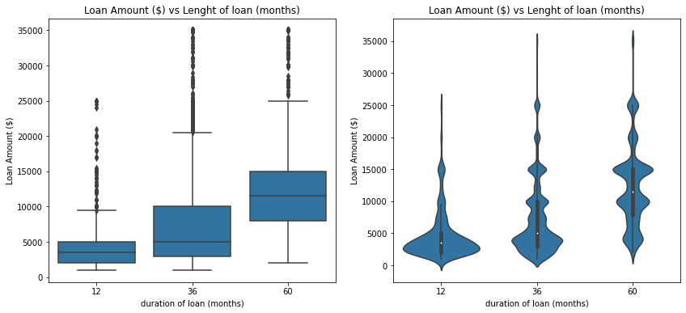

#### It is observed from this plot that the larger loans have longer durations

## Is there a relationship between term and employment Status

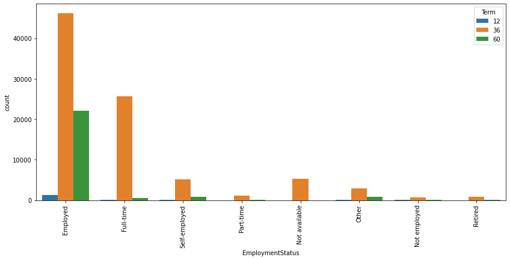

## Whats the relationship between the borrower annual percentage and the debt to income ratio

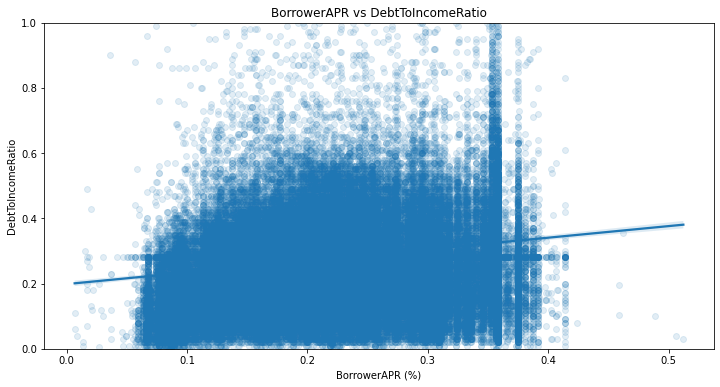

#### From the plot it can be seen that the higher the Debt to Income Ratio, the higher the borrower annual percentage rate. Which means the more one is in debt, the more expensive it is to take loans

## Whats the relationship between the borrower annual percentage and the Loan Original amount

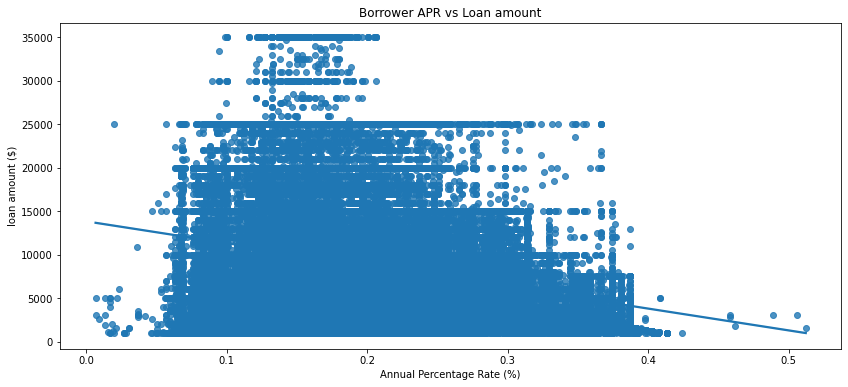

#### There is a negative correlation between rthe loan amount and the annual percentage rate, the plot shows that lower loan amount attracts higher borrower APR

## Does the employment status of individual have implications on the borrower APR

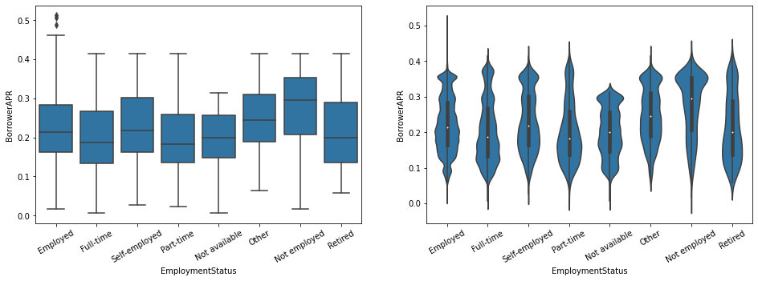

#### People with jobs tends to have lower APR compared to those without one

## Does the Income Range of individual have implications on the Loan Amount?

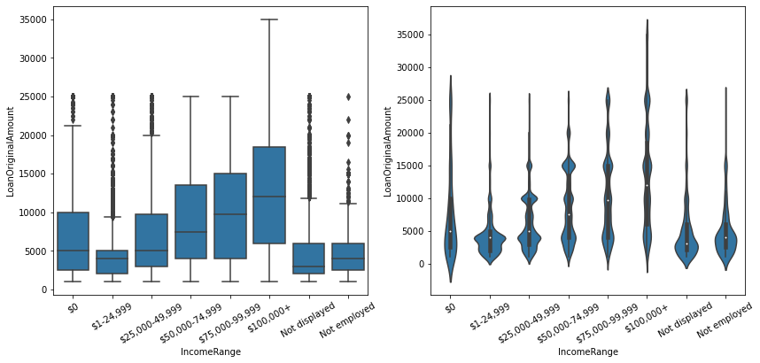

#### It can be observed from the above plot that the amount giving as loans increases with Income range, individuals that are not employed or earn less get low figures as loans

## Whats the influence of the Income Range on the borrower APR

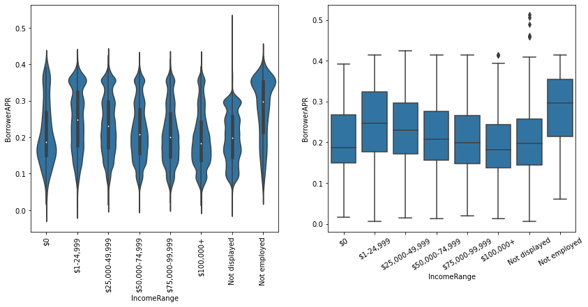

#### The borrower APR tends to be higher for the non employed and the low income earners, as income range increases, Borrower Annual Percentage rate reduces

### Talk about some of the relationships you observed in this part of the investigation. How did the feature(s) of interest vary with other features in the dataset?

> Its noticed that the debt to income ratio positively affects the borrower apr, while an increase in the loan amount reduces the Borrower APR. Individuals that are employed and with jobs tend to attract lower apr's too, so as the income range increases, the borrower APR decreases.

### Did you observe any interesting relationships between the other features (not the main feature(s) of interest)?

> Yes, there are other relationships between other features; the loan amount and income range have a positive relation where its noticed that with an increase in income range the loan amount also increases, and the larger the amount of loan the term duration of the loan increases too.

## In earlier analysis it was noticed that the income range influenced the borrower apr, is this influence uniform across the three duration?

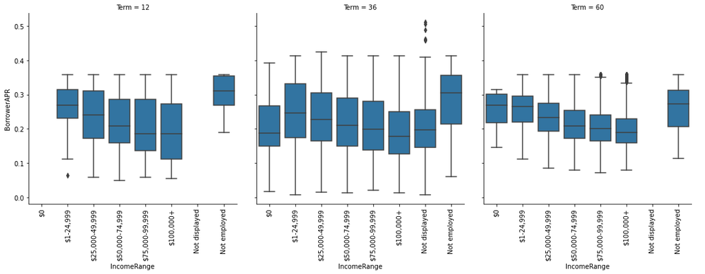

#### From the above plot it a similar pattern can be observed across all three terms, there is a sharp decrease in the Borrower APR with an Increase in Income Range irregardless of the duration of the loan

## What is the influence of having a document to proof income on the Borrowerapr

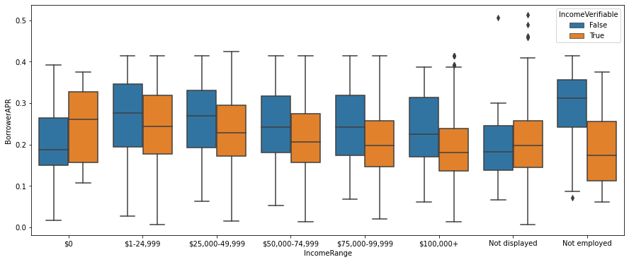

### Were there any interesting or surprising interactions between features?

> The very clear difference between incomeverifiable categories in the not employed class.

## Conclusions

> The explored features in the dataset revealed that the incomerange, loan amount, debt to income ratio and income verifiable influenced the Annual Percentage Rate attached to each loan entry and should be considered while applying for a loan next.